# Basic statistics for health research - week 2, ex. 1

Benjamin Skov Kaas-Hansen

11/2/2021

### Setup and loading packages

```r
# Set default alignment of figures
knitr::opts_chunk$set(fig.align = "center")

# Data manipulation
library(dplyr)
library(tidyr)
library(readr)
library(scales) # for the percent() function

# Modelling
library(broom) # for tidy()

# Data visualiation
library(ggplot2)
library(lindia) # for diagnostic plots of (generalised) linear models
theme_set(theme_minimal()) # sets default theme for ggplots
```

### Helper functions

```r
pretty_estimates <- function(m) { # m: model object
    cbind(Est. = m$coefficients, confint(m))
}
```

### Importing and wrangling data

Note how there’s an empty column because all lines in the input file ends with a white space. It’s automatically given the name `X4` by R, so I remove (“de-select”) it. Usually you’d want to make sure that the database (or whatever source you have) doesn’t produce such artefacts. Also note that if you use `read.csv` this column won’t show up; I prefer, however, to know exactly what the data file looks like as this helps me prevent errors (“gargage-in-garbage-out”).

I prefer to keep all data wrangling in one place, even though you only find out as you go through your analysis. It’s an iterative process. *Remember* to encode your categorical variables as `factor`s so R knows to treat handle them correctly. Also, it gives you the possibility to give them useful labels.

```r
df <- read_delim("http://staff.pubhealth.ku.dk/~sr/BasicStatistics/datasets/oeko.txt", delim = " ", na = ".") %>%
    transmute(sas_employee = factor(sas_ansat, c("nej", "ja"), c("No", "Yes")),
              abs_time = factor(abstid, 1:3, c("Short", "Medium", "Long")),
              concentration = konc,
              log10_concentration = log10(concentration))
glimpse(df) # gives a nice overview of the actual values in the dataframe ≠ summary()
```

```
## Rows: 188
## Columns: 4
## $ sas_employee        <fct> Yes, Yes, Yes, Yes, Yes, Yes, Yes, Yes, Yes, Yes,…
## $ abs_time            <fct> Long, Long, Long, Medium, Long, Long, Medium, Lon…
## $ concentration       <dbl> 26, 12, 83, 36, 111, 18, 77, 122, 77, 18, 22, 107…
## $ log10_concentration <dbl> 1.414973, 1.079181, 1.919078, 1.556303, 2.045323,…
```

Get a few summary stats; we have 188 observations with 4 variables.

```r
summary(df)
```

```
##  sas_employee   abs_time  concentration    log10_concentration
##  No : 53      Short :37   Min.   :  0.75   Min.   :-0.1249
##  Yes:135      Medium:63   1st Qu.: 28.25   1st Qu.: 1.4505
##               Long  :88   Median : 57.00   Median : 1.7559
##                           Mean   : 79.65   Mean   : 1.7011
##                           3rd Qu.:100.00   3rd Qu.: 2.0000
##                           Max.   :402.00   Max.   : 2.6042
```

### 1. Illustration of data

Start by disregarding the abstinence variable:

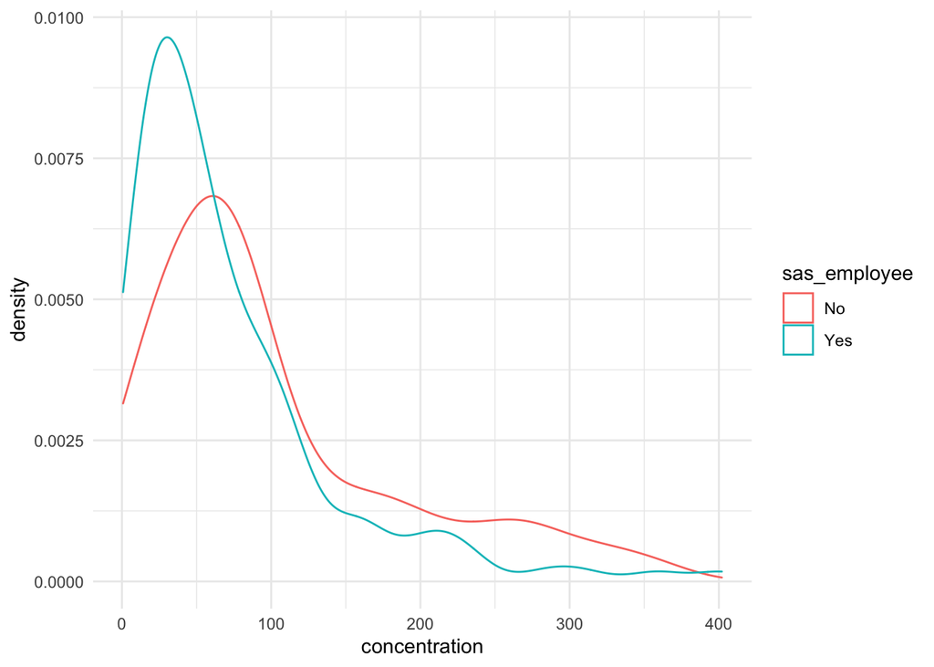

```r
ggplot(df, aes(x = concentration, colour = sas_employee)) +
    geom_density()
```

The concentration is non-negative and has a long tail on the right so a log-transformation could be useful. Often biomarkers and the like are right-skewed because they can’t go below zero, most people are somewhat closer to zero, and some are more extreme (creating the tail). It seems a log-transformed variable is better suited than the original.

If you want to illustrate the log-transformed data, it’s equivalent to the plot above but with another variable on the x axis:

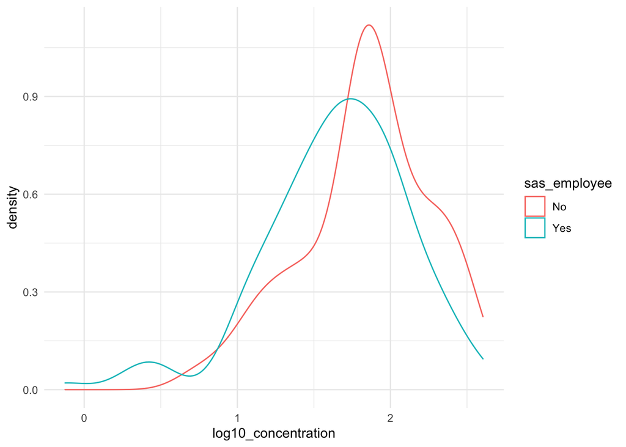

```r
ggplot(df, aes(x = log10_concentration, colour = sas_employee)) +
    geom_density()
```

If you, however, want to illustrate your original data but on a log-scale, you need to scale the axis (note how this plot is identical to the one above except the tick labels on the x axis.)

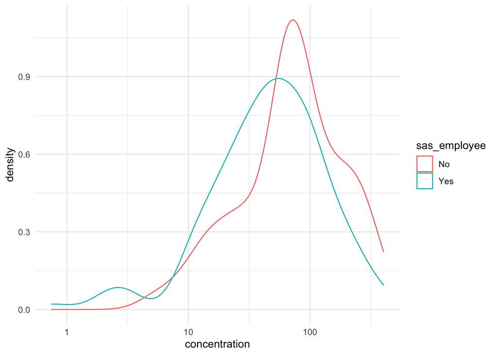

```r
ggplot(df, aes(x = concentration, colour = sas_employee)) +
    geom_density() +
    scale_x_log10()
```

### 2. Quantify and compare concentration

#### a. Estimate concentrations

As you can see, 1.96 would be an excellent approximation to the “circa 2” factor.

```r
df %>%
    group_by(sas_employee) %>%
    summarise(mean_log10 = mean(log10_concentration),
              sem_log10 = sqrt(1 / n()) * sd(log10_concentration),
              circa_2 = qt(0.975, n() - 1),
              ci_lo_log10 = mean_log10 - circa_2 * sem_log10,
              ci_hi_log10 = mean_log10 + circa_2 * sem_log10,
              mean = 10^mean_log10,
              ci_lo = 10^ci_lo_log10,
              ci_hi = 10^ci_hi_log10)
```

| sas_employee | mean_log10 | sem_log10 | circa_2 | ci_lo_log10 | ci_hi_log10 | mean | ci_lo | ci_hi |
| --- | --- | --- | --- | --- | --- | --- | --- | --- |
| No | 1.834576 | 0.0576607 | 2.006647 | 1.718872 | 1.950281 | 68.32450 | 52.34459 | 89.18280 |
| Yes | 1.648640 | 0.0405816 | 1.977826 | 1.568377 | 1.728903 | 44.52869 | 37.01490 | 53.56774 |

#### b. Compare the estimates

The 95% confidence intervals has a slight overlap suggesting difference between the means in the two groups. Note that the CI only says something about the expected value of the *mean* not about the distribution of concentrations in the two groups.

#### c. + d. Compare distributions with t test

This does not assume equal variance in the two groups, and comes out with a p value of 0.010 (so significant). Note that the difference is on the multiplicative scale due to the log-transformation. Because $\log A - \log B = \log(A/B)$ so when you back-transform, we get the ratio between the two and not the differnece.

```r
t.test(log10_concentration ~ sas_employee, data = df) %>%
    tidy()
```

| estimate | estimate1 | estimate2 | statistic | p.value | parameter | conf.low | conf.high | method | alternative |
| --- | --- | --- | --- | --- | --- | --- | --- | --- | --- |
| 0.1859365 | 1.834576 | 1.64864 | 2.637033 | 0.0096186 | 106.1651 | 0.0461466 | 0.3257264 | Welch Two Sample t-test | two.sided |

A test of equal variance actually suggests that variance not be different, so we could use that in the t test:

```r
var.test(log10_concentration ~ sas_employee, data = df)
```

```
##
##  F test to compare two variances
##
## data:  log10_concentration by sas_employee
## F = 0.79258, num df = 52, denom df = 134, p-value = 0.3414
## alternative hypothesis: true ratio of variances is not equal to 1
## 95 percent confidence interval:
##  0.5137256 1.2809072
## sample estimates:
## ratio of variances
##          0.7925803
```

```r
t.test(log10_concentration ~ sas_employee, data = df, var.equal = TRUE)
```

```
##
##  Two Sample t-test
##
## data:  log10_concentration by sas_employee
## t = 2.5065, df = 186, p-value = 0.01305
## alternative hypothesis: true difference in means is not equal to 0
## 95 percent confidence interval:
##  0.03959027 0.33228274
## sample estimates:
##  mean in group No mean in group Yes
##          1.834576          1.648640
```

### 3. Sub-divide by abstinence time

A few plots. Now that we have a third dimension (abstinence time), normal density plots become less useful.

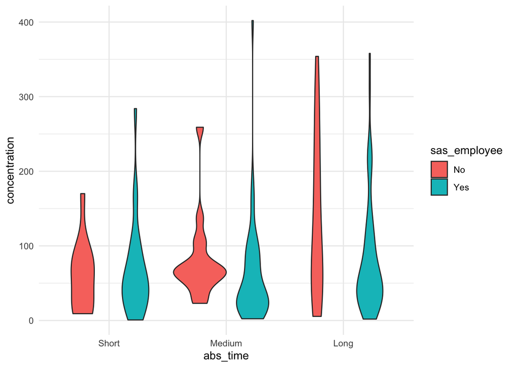

```r
ggplot(df, aes(x = abs_time, y = concentration, fill = sas_employee)) +
    geom_violin()
```

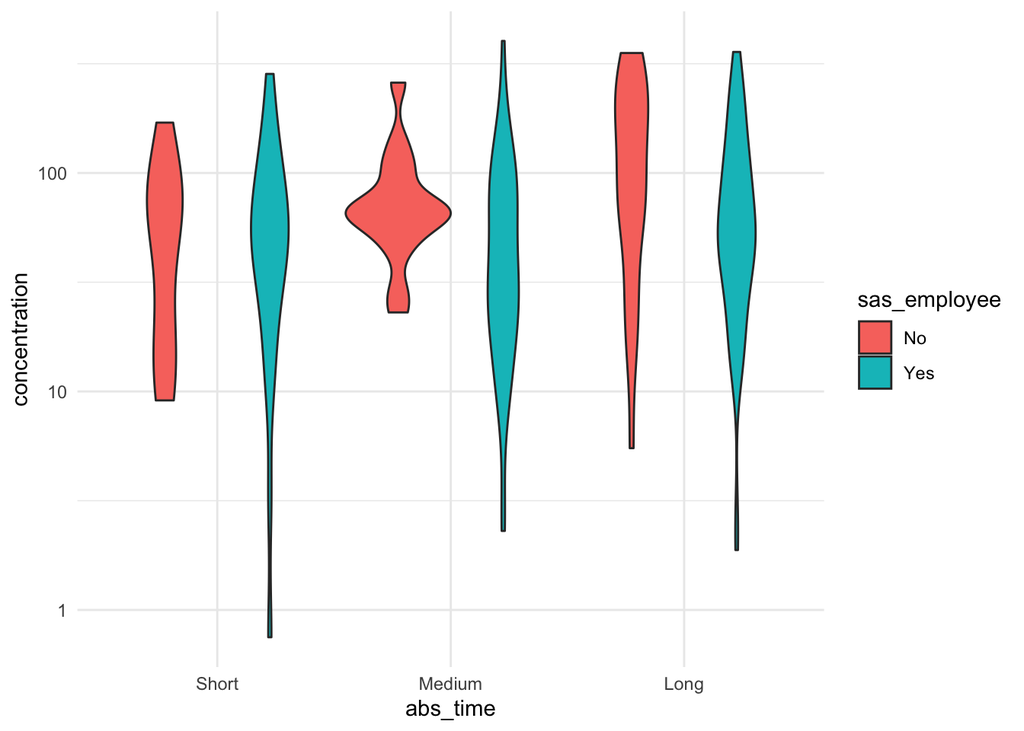

```r
ggplot(df, aes(x = abs_time, y = concentration, fill = sas_employee)) +
    geom_violin() +
    scale_y_log10()
```

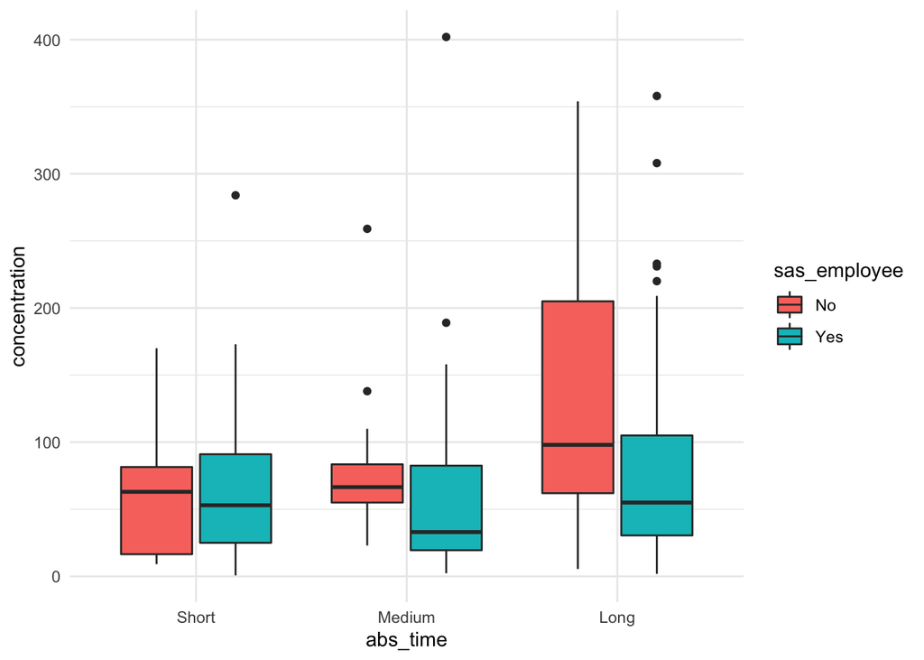

```r
ggplot(df, aes(x = abs_time, y = concentration, fill = sas_employee)) +
    geom_boxplot()
```

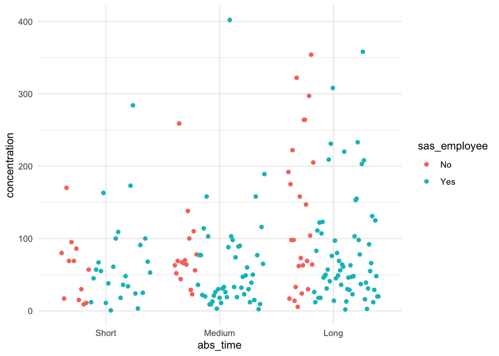

```r
# This scatterplot-like plot isn't ideal
ggplot(df, aes(x = abs_time, y = concentration, colour = sas_employee)) +
    geom_jitter(position = position_dodge2(width = 0.8))
```

Use `facet_wrap()` to put each level of abstinence time in its own sub-plot (instead of putting it on the x axis). The second plot has a log-transformed x axis.

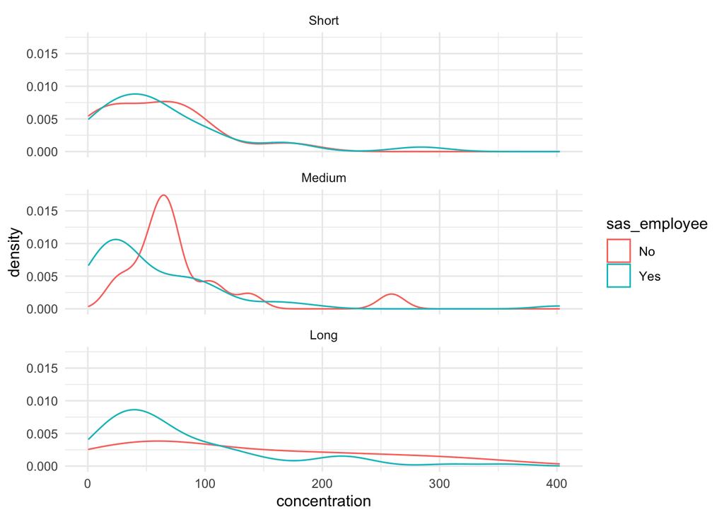

```r
ggplot(df, aes(x = concentration, colour = sas_employee)) +
    geom_density() +
    facet_wrap(~ abs_time, ncol = 1)
```

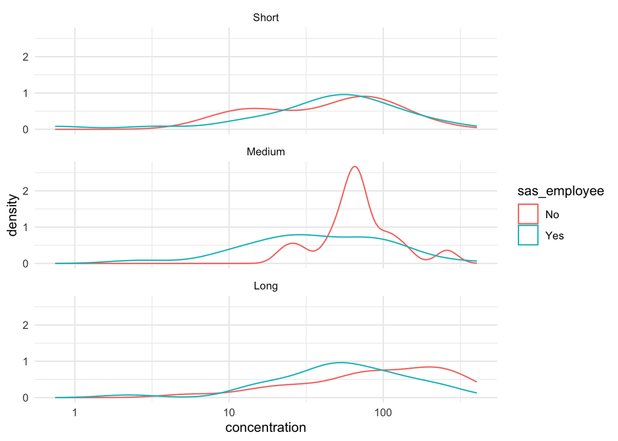

```r
ggplot(df, aes(x = concentration, colour = sas_employee)) +
    geom_density() +
    scale_x_log10() +
    facet_wrap(~ abs_time, ncol = 1)
```

#### Summary stats

```r
df %>%
    group_by(sas_employee, abs_time) %>%
    summarise(mean_log10 = mean(log10_concentration),
              sem_log10 = sqrt(1 / n()) * sd(log10_concentration),
              circa_2 = qt(0.975, n() - 1),
              ci_lo_log10 = mean_log10 - circa_2 * sem_log10,
              ci_hi_log10 = mean_log10 + circa_2 * sem_log10,
              mean = 10^mean_log10,
              ci_lo = 10^ci_lo_log10,
              ci_hi = 10^ci_hi_log10,
              n_obs = n()) %>%
    ungroup() %>% # remove grouping
    mutate(prop_obs = percent(n_obs / sum(n_obs)))
```

| sas_employee | abs_time | mean_log10 | sem_log10 | circa_2 | ci_lo_log10 | ci_hi_log10 | mean | ci_lo | ci_hi | n_obs | prop_obs |
| --- | --- | --- | --- | --- | --- | --- | --- | --- | --- | --- | --- |
| No | Short | 1.613619 | 0.1210528 | 2.200985 | 1.347184 | 1.880054 | 41.07893 | 22.24251 | 75.86728 | 12 | 6.4% |
| No | Medium | 1.834595 | 0.0620553 | 2.131449 | 1.702327 | 1.966863 | 68.32744 | 50.38804 | 92.65371 | 16 | 8.5% |
| No | Long | 1.940624 | 0.0951972 | 2.063899 | 1.744147 | 2.137101 | 87.22159 | 55.48129 | 137.12019 | 25 | 13.3% |
| Yes | Short | 1.604561 | 0.1103136 | 2.063899 | 1.376885 | 1.832238 | 40.23107 | 23.81691 | 67.95755 | 25 | 13.3% |
| Yes | Medium | 1.567940 | 0.0665754 | 2.012896 | 1.433931 | 1.701950 | 36.97772 | 27.16007 | 50.34420 | 47 | 25.0% |
| Yes | Long | 1.726336 | 0.0558251 | 1.998971 | 1.614743 | 1.837929 | 53.25200 | 41.18539 | 68.85393 | 63 | 33.5% |

The `stat_summary` is useful for plotting e.g. mean and uncertainty intervals; `"mean_cl_boot"` produces non-parametric confidence intervals. I dodge the points and lineranges to we can see them. It seems that the mean changes with abstinence time for non-employees unlike for the employees (mean between 60 and 80 with no obvious trend, although there could be a slight upward trend within the confidence limits.)

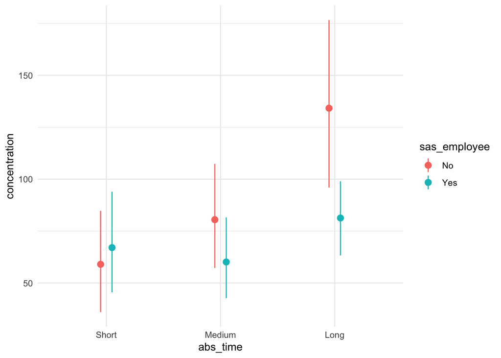

```r
ggplot(df, aes(x = abs_time, y = concentration, colour = sas_employee)) +
    stat_summary(fun.data = "mean_cl_boot", position = position_dodge2(width = 0.2))
```

### 4. ANOVA model

```r
mod <- lm(log10_concentration ~ abs_time + sas_employee, data = df)
summary(mod)
```

```
##
## Call:
## lm(formula = log10_concentration ~ abs_time + sas_employee, data = df)
##
## Residuals:
##      Min       1Q   Median       3Q      Max
## -1.67182 -0.25675  0.03867  0.29830  1.01603
##
## Coefficients:
##                 Estimate Std. Error t value Pr(>|t|)
## (Intercept)      1.73379    0.08946  19.381   <2e-16 ***
## abs_timeMedium   0.04131    0.09389   0.440   0.6605
## abs_timeLong     0.18723    0.08874   2.110   0.0362 *
## sas_employeeYes -0.18691    0.07348  -2.543   0.0118 *
## ---
## Signif. codes:  0 '***' 0.001 '**' 0.01 '*' 0.05 '.' 0.1 ' ' 1
##
## Residual standard error: 0.4526 on 184 degrees of freedom
## Multiple R-squared:  0.06387,    Adjusted R-squared:  0.0486
## F-statistic: 4.184 on 3 and 184 DF,  p-value: 0.006803
```

```r
# Get estimate on the log10 scale
pretty_estimates(mod)
```

```
##                        Est.       2.5 %      97.5 %
## (Intercept)      1.73378673  1.55729227  1.91028119
## abs_timeMedium   0.04131289 -0.14393631  0.22656208
## abs_timeLong     0.18723395  0.01215977  0.36230813
## sas_employeeYes -0.18690564 -0.33188495 -0.04192633
```

```r
# Get estimates on the real scale (bottom row is the answer)
10^pretty_estimates(mod)
```

```
##                      Est.      2.5 %     97.5 %
## (Intercept)     54.173479 36.0821389 81.3356959
## abs_timeMedium   1.099798  0.7178996  1.6848532
## abs_timeLong     1.538983  1.0283946  2.3030753
## sas_employeeYes  0.650271  0.4657094  0.9079745
```

```r
anova(mod)
```

|  | Df | Sum Sq | Mean Sq | F value | Pr(>F) |
| --- | --- | --- | --- | --- | --- |
| abs_time | 2 | 1.246498 | 0.6232490 | 3.041959 | 0.0501493 |
| sas_employee | 1 | 1.325467 | 1.3254671 | 6.469351 | 0.0117977 |
| Residuals | 184 | 37.698672 | 0.2048841 | NA | NA |

Let’s take a look at the predicted values from the model (to see if there’s sign of interaction). The mappings (so what’s inside the `aes` call) set in `ggplot` are shared across all layers, so below both the lines and points get their coordinators and colour specifications from the “global” setting.

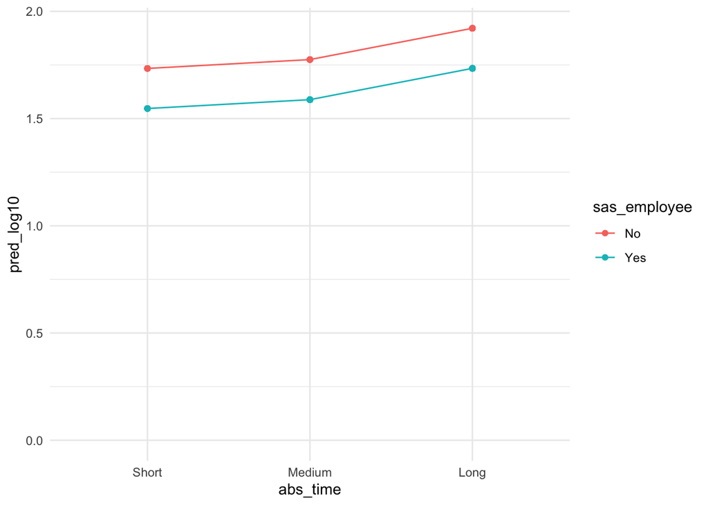

```r
df %>%
    mutate(pred_log10 = predict(mod)) %>%
    ggplot(aes(x = abs_time, y = pred_log10, colour = sas_employee, group = sas_employee)) +
        geom_line() +
        geom_point() +
        scale_y_continuous(limits = c(0, NA)) # forces the y axis to start in (0,0)
```

But we have actually made a multiple linear regression model, and we should do some controls to ascertain that the assumptions of such models are met. The `lindia` package is quite nifty for these plots.

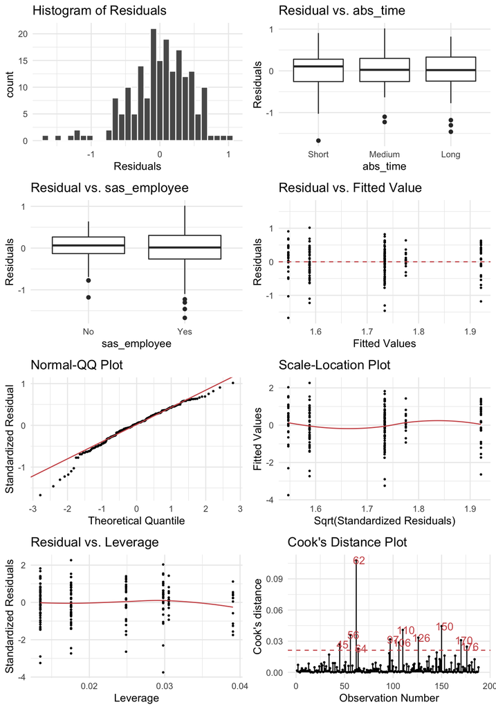

```r
gg_diagnose(mod)
```

#### Interaction model

I’m leaving this out for now as it’s basically the same again and we come back to linear models and interactions therein later.